# Random Forest in practice

Pietro Franceschi

12/11/2020

```r
library(tidyverse)
library(randomForest)
```

## Introduction

The objective of this demo, and of the subsequent DIY, is to make you familiar RandomForest, by applying it to two classification tasks of metabolomics data.

These are the steps we will follow

1. Load the KOMP targeted metabolomics dataset we used two days ago, our objective will be to classify the mouse gender
2. Impute missing values with our old “analytical” approach
3. Split the data in training and test sets
4. Train our RF model and optimize the model parameters
5. Evaluate how much we are good in prediction on the test set
6. Look to the variable importance in a model build on all the data

A couple of preliminary messages

- **Imputation**: RF can be used also to perform imputation (there is an `rfImpute` function in the package!). It would be for sure interesting to compare rf imputation with our approach.
- **Test Set**: in the demo we would only test our approach once. This is fine for illustration purposes, but with a single test set we cannot estimate how big is the variability of our prediction. In order to do that it would be necessary to have a *set* of tests set … this is normally performed by repeating the training-tuning-test workflow in a cross validation scheme.

## 1. Get the data

This we already know …

```r
load("../Day2/KOMP_data_targeted.RData")
```

We have now three files

- the description of the metabolites
- the description of the samples
- the actual data matrix

```r
DM <- DM %>%
  as.data.frame() %>%
  column_to_rownames("CompoundID") %>%
  t(.) %>%
  as_tibble(rownames = "Sampname") %>%
  separate(Sampname, c("One","MouseID"),"_") %>% ## split the column
  select(-One) %>%   ## remov the first piece
  mutate(MouseID = as.numeric(MouseID))
```

## 2. Impute missing values

```r
myimputer <- function(v){
  if (sum(is.na(v)) == 0) {
    return(v)
  } else {
    napos <- which(is.na(v))
    newval <- runif(length(napos),0,min(v, na.rm = TRUE))
    out <- v
    out[napos] <- newval
    return(out)
  }

}
```

Now we apply it to the full set of columns

```r
DM_i <- DM %>%
  mutate(across(starts_with("CPD"), ~myimputer(.x)))
```

I’m formatting the data to be used for a RandomForest analysis, so I should give a look to the help of the package to be sure my data are OK.

The absence of a coherent way to perform machine learning in R is a typical situation one have to face. If you are interested on a specific method this is not a huge problem, but when you would like to try different methods and check which is the best one the situation starts to be tricky. The community has (and is) developing several solutions to cope with that.

We need a df with the column with the factor we want to predict…

```r
rf_df <- DM_i %>%
  left_join(sample_meta_data) %>%
  select(c(Gender,starts_with("CPD"))) %>%
  mutate(Gender = factor(Gender))
```

## 3. Split the data in training and test sets

The situation with the samples is the following

```r
table(rf_df$Gender)
```

```
##
## Female   Male
##    110    110
```

We need to split the data in training and test sets, doing it completely at random way could result in the unfortunate situation of having a test set composed mainly (if not exclusively!) of samples belonging to a single class.

To avoid that we need to use **stratified sampling**, a concept we already introduced in the first day of the course.

Here the situation is easy, since we have two perfectly balanced sample groups.

In general is preferred to split the data in training an test keeping more samples in the training set. This is done in order to be able to construct a model with less bias. More training samples will result in a model constructed with more data !

In our example we will partition the data in leaving the 10% of the samples in the test set.

```r
set.seed(123)
## let's fo it with brute force

work_df <- rf_df %>%
  nest(data = starts_with("CPD")) %>%
  mutate(testid = map(data, ~sample(1:nrow(.x),11))) %>%
  mutate(training = map2(data,testid, ~.x %>% slice(-.y))) %>%
  mutate(test = map2(data,testid, ~.x %>% slice(.y)))

## now we build the training and test dfs

training_df <- work_df %>%
  select(Gender,training) %>%
  unnest(training)


test_df <- work_df %>%
  select(Gender,test) %>%
  unnest(test)
```

## 4. Train our RF model and optimize the model parameters

Now we are ready to train the RF

```r
rfmodel <- randomForest(Gender~., data = training_df)

rfmodel
```

```
##
## Call:
##  randomForest(formula = Gender ~ ., data = training_df)
##                Type of random forest: classification
##                      Number of trees: 500
## No. of variables tried at each split: 7
##
##         OOB estimate of  error rate: 5.05%
## Confusion matrix:
##        Female Male class.error
## Female     94    5  0.05050505
## Male        5   94  0.05050505
```

Let’s now dissect the output:

- `Type of random forest: classification`: tells that we are doing a classification
- `Number of trees: 500`: this is the number of trees of our forest. 500 is the default
- `No. of variables tried at each split: 7`: this is the number of variables which is randomly taken into consideration at each split of each node
- `OOB estimate of error rate`: since we do bootstrap on the samples, some of them are already left out (out-of-bag) and are used as an independent measure of the error rate on the training set
- `Confusion Matrix`: this split up the error rate in the two classes showing the class-specific misclassification rate

Apparently our RF is working well! This should be not unexpected considering the results of the univariate analysis we performed on Day2.

Let’s look if the model parameters were correctly set.

For `ntres` the training process itself can be used to check if it was necessary to increase the number of trees. The evolution of the OOB errors as the “forest” grows from 1 to 500 trees are stores inside the model

```r
head(rfmodel$err.rate)
```

```
##             OOB     Female       Male
## [1,] 0.14102564 0.20000000 0.07894737
## [2,] 0.09836066 0.08620690 0.10937500
## [3,] 0.12751678 0.11111111 0.14285714
## [4,] 0.12865497 0.09302326 0.16470588
## [5,] 0.16022099 0.14285714 0.17777778
## [6,] 0.12169312 0.10526316 0.13829787
```

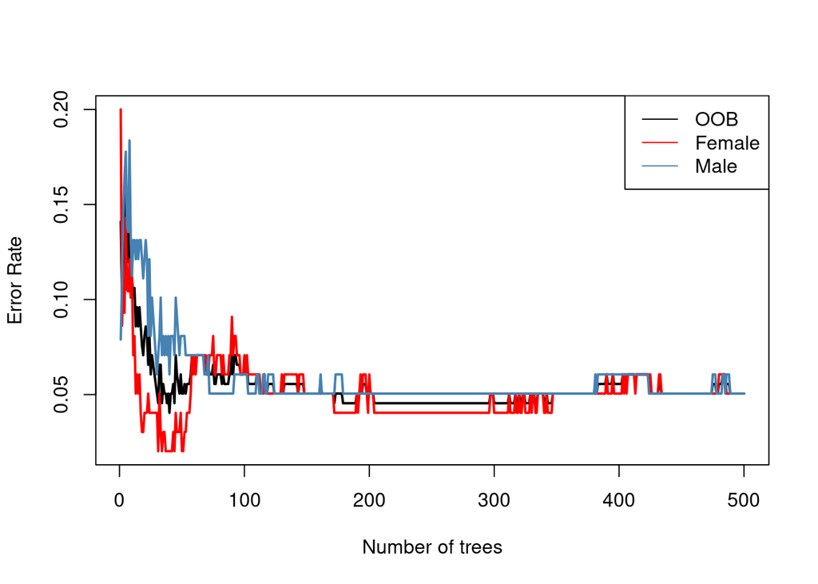

```r
matplot(rfmodel$err.rate, type = "l", col = c("black","red","steelblue"),
        xlab = "Number of trees",
        ylab = "Error Rate",
        lwd = 2, lty = 1)
legend("topright", legend = colnames(rfmodel$err.rate), col = c("black","red","steelblue"), lty = 1)
```

As you can see the error rate stabilizes already with a forest of 150 trees. There is no point, then, to change the default value of this parameter in our model.

The testing of `mtry` have to be done by hand

```r
## create a testing tibble with the values
mtrytest <-tibble(mtry = 1:25) %>%
  mutate(rfs = map(mtry, ~randomForest(Gender~., data = training_df, mtry = .x))) ## run the battery of models
```

now we have to get out the error rates and plot them

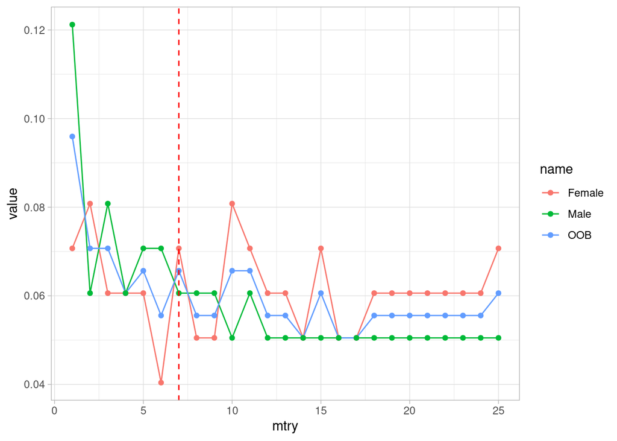

```r
mtrytest %>%
  mutate(err = map(rfs, ~.x$err.rate[500,])) %>%
  unnest_wider(err) %>%
  select(-rfs) %>%
  pivot_longer(-mtry) %>%
  ggplot(aes(x = mtry, y = value, col = name)) +
  geom_line() +
  geom_point() +
  geom_vline(xintercept = 7, col = "red", lty = 2) +
  theme_light()
```

```r
bestrf <- randomForest(Gender~., data = training_df, mtry = 6)
bestrf
```

```
##
## Call:
##  randomForest(formula = Gender ~ ., data = training_df, mtry = 6)
##                Type of random forest: classification
##                      Number of trees: 500
## No. of variables tried at each split: 6
##
##         OOB estimate of  error rate: 6.06%
## Confusion matrix:
##        Female Male class.error
## Female     92    7  0.07070707
## Male        5   94  0.05050505
```

## 5. Evaluate how much we are good in prediction on the test set

Now is time to look to the prediction on the test set

```r
pred <- predict(bestrf,test_df)
```

And now we can calculate the confusion matrix

```r
cm <-  table(test_df$Gender, pred)
cm
```

```
##         pred
##          Female Male
##   Female     11    0
##   Male        0   11
```

As we discusses at the beginning, we would also need an estimate of the variability in the prediction error, and to do that all our approach should be included in a repeated validation scheme.

## 6. Look to the variable importance in a model build on all the data

The last step of our analysis is to identify the variables which are more important to differentiate males and females. To do that, we first construct a model on all the data (to have the minimum possible bias), and then we look to the variable importance in that model

```r
full_model <- randomForest(Gender~., data = rf_df, mtry = 8)


full_model
```

```
##
## Call:
##  randomForest(formula = Gender ~ ., data = rf_df, mtry = 8)
##                Type of random forest: classification
##                      Number of trees: 500
## No. of variables tried at each split: 8
##
##         OOB estimate of  error rate: 5.45%
## Confusion matrix:
##        Female Male class.error
## Female    105    5  0.04545455
## Male        7  103  0.06363636
```

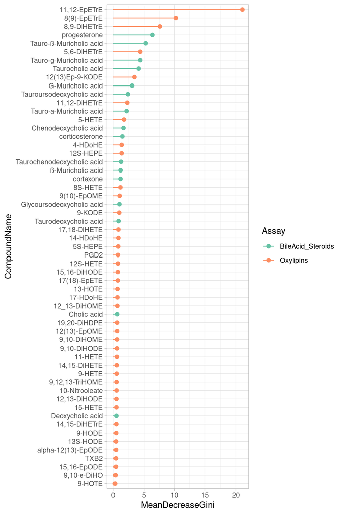

```r
full_model$importance %>%
  as_tibble(rownames = "CompoundID") %>%
  left_join(metabolite_meta) %>%
  arrange(`MeanDecreaseGini`) %>%
  mutate(CompoundName = factor(CompoundName, levels = CompoundName)) %>%
  ggplot() +
  geom_point(aes(x = CompoundName,  y= `MeanDecreaseGini`, col = Assay), size = 2) +
  geom_segment(aes(x = CompoundName,  yend = `MeanDecreaseGini`, col = Assay, xend = CompoundName, y = 0)) +
  scale_color_brewer(palette = "Set2") +
  coord_flip() +
  theme_light()
```

Which gives a picture slightly different from our old univariate analysis. Remember, however, that RF is a supervised multivariate classifier, not a univariate approach …